# Lab 3, Student Performance Dataset

Team Members: Sandro Juric & Scotty Seethoff

### AI usage disclaimer

We have used the Copilot in this project, primarily for code refactoring in VS Code

# Business Understanding

### Overview & purpose:

This is synthetically generated dataset of 5000 student with several key demographic data including age, gender, academic level. Accompanied by several features we can use to predict classifies of focus index, burnout level, productivity score, and exam score. Assuming we can build a accurate prediction model that can determine these classes based on features of number of study hours, self-study hours, online classes, number of social media hours, gaming hours, sleep hours, screen time hours, excise amounts, caffeine intake, internet quality, and mental health score once we are able to obtain real time data we could better devise plans to help out students be more successful, productive, and increase their focus index, while keeping the burnout level low. Even though this data set was generated synthetically, data has realistic relationship between features that can be used to simulate real world scenarios.

### Data Imporatance:

School administrators struggle on a daily basis to improve the overall education of all the students. It would be a great benefit to know what factors have the most effect on the overall student scores, their productivity, and their burn out level. The educators have to balance the given the students enough study material to be successful versus overwhelming them with too material. If we can build a high confidence model this balancing task would be greatly simplified.

### Benchmark Test

As mentioned above we'll need to have at least 85% accuracy to achieve confidence in predicting exam scores. We'll use multi different algorithms to achieve that goal and will weigh accuracy with the amount of computing power that is needed.

### Original Dataset:

Dataset: https://www.kaggle.com/datasets/amar5693/student-performance-dataset

# Data Preparation

Importing the data from static offline CSV file. Removing unnecessary variables and converting gender, academic level, and internet quality to integer map. Examining the data structure and sample records. Finally, looking over the statistical analysis of the dataset to see if there are any outliers that will need additional data manipulation before proceeding with the prediction task.

```python
import pandas as pd
import numpy as np

# Suppress SettingWithCopyWarning
pd.options.mode.chained_assignment = None  # default='warn'
# Ensure future behavior for downcasting is explicit
pd.set_option('future.no_silent_downcasting', True)

df = pd.read_csv('ultimate_student_productivity_dataset_5000.csv')

# select relevant columns
dfSelect = df[['student_id', 'age', 'gender', 'academic_level', 'study_hours', 'self_study_hours', 'online_classes_hours', 'social_media_hours', 'gaming_hours', 'sleep_hours', 'screen_time_hours', 'exercise_minutes', 'caffeine_intake_mg', 'internet_quality', 'mental_health_score', 'focus_index', 'burnout_level', 'productivity_score', 'exam_score']]

gender_map = {
    'Other': 0,
    'Male': 1,
    'Female': 2
}

academic_level_map = {
    'High School': 1,
    'Undergraduate': 2,
    'Graduate': 3,
    'PhD': 4
}

internet_quality_map = {
    'Poor': 1,
    'Average': 2,
    'Good': 3,
    'Excellent': 4
}

dfSelect['gender'] = dfSelect['gender'].map(gender_map).fillna(0)
dfSelect['academic_level'] = dfSelect['academic_level'].map(academic_level_map).fillna(0)
dfSelect['internet_quality'] = dfSelect['internet_quality'].map(internet_quality_map).fillna(0)


dfSelect.info()
# format and display of the first few rows used the pandas Styler for better visualization in Jupyter Notebooks https://pandas.pydata.org/docs/user_guide/style.html
display(dfSelect.head(10).style.background_gradient(axis=None, cmap="YlGnBu"))

dfSelect.describe().style.background_gradient(cmap="YlOrRd")
```

```
<class 'pandas.core.frame.DataFrame'>
RangeIndex: 5000 entries, 0 to 4999
Data columns (total 19 columns):
 #   Column                Non-Null Count  Dtype
---  ------                --------------  -----
 0   student_id            5000 non-null   int64
 1   age                   5000 non-null   int64
 2   gender                5000 non-null   int64
 3   academic_level        5000 non-null   float64
 4   study_hours           5000 non-null   float64
 5   self_study_hours      5000 non-null   float64
 6   online_classes_hours  5000 non-null   float64
 7   social_media_hours    5000 non-null   float64
 8   gaming_hours          5000 non-null   float64
 9   sleep_hours           5000 non-null   float64
 10  screen_time_hours     5000 non-null   float64
 11  exercise_minutes      5000 non-null   int64
 12  caffeine_intake_mg    5000 non-null   int64
 13  internet_quality      5000 non-null   int64
 14  mental_health_score   5000 non-null   int64
 15  focus_index           5000 non-null   float64
 16  burnout_level         5000 non-null   float64
 17  productivity_score    5000 non-null   float64
 18  exam_score            5000 non-null   float64
dtypes: float64(12), int64(7)
memory usage: 742.3 KB
```

|  | student_id | age | gender | academic_level | study_hours | self_study_hours | online_classes_hours | social_media_hours | gaming_hours | sleep_hours | screen_time_hours | exercise_minutes | caffeine_intake_mg | internet_quality | mental_health_score | focus_index | burnout_level | productivity_score | exam_score |
| --- | --- | --- | --- | --- | --- | --- | --- | --- | --- | --- | --- | --- | --- | --- | --- | --- | --- | --- | --- |
| 0 | 1 | 18 | 0 | 1.000000 | 7.640000 | 1.560000 | 2.200000 | 3.050000 | 2.190000 | 6.520000 | 6.470000 | 81 | 38 | 3 | 10 | 43.050000 | 31.770000 | 73.650000 | 50.160000 |
| 1 | 2 | 18 | 0 | 1.000000 | 2.210000 | 2.220000 | 2.100000 | 1.650000 | 2.550000 | 5.970000 | 6.050000 | 111 | 339 | 3 | 3 | 15.920000 | 37.000000 | 13.700000 | 1.000000 |
| 2 | 3 | 22 | 1 | 1.000000 | 3.450000 | 0.000000 | 0.290000 | 1.340000 | 2.080000 | 8.390000 | 7.620000 | 68 | 266 | 3 | 8 | 27.390000 | 34.370000 | 45.150000 | 18.300000 |
| 3 | 4 | 17 | 0 | 1.000000 | 5.750000 | 2.080000 | 3.010000 | 2.270000 | 2.200000 | 6.310000 | 11.670000 | 113 | 480 | 1 | 3 | 22.310000 | 77.310000 | 20.920000 | 9.370000 |
| 4 | 5 | 19 | 0 | 1.000000 | 6.830000 | 1.720000 | 3.330000 | 2.650000 | 0.700000 | 8.010000 | 10.020000 | 121 | 24 | 3 | 8 | 38.110000 | 39.530000 | 59.230000 | 27.810000 |
| 5 | 6 | 25 | 1 | 2.000000 | 2.210000 | 3.500000 | 1.690000 | 4.470000 | 1.560000 | 8.340000 | 8.060000 | 110 | 288 | 2 | 8 | 30.520000 | 33.640000 | 36.200000 | 18.530000 |
| 6 | 7 | 22 | 0 | 1.000000 | 4.600000 | 2.370000 | 1.270000 | 3.120000 | 1.890000 | 7.610000 | 11.340000 | 19 | 123 | 1 | 6 | 33.260000 | 62.010000 | 37.590000 | 10.350000 |
| 7 | 8 | 17 | 1 | 1.000000 | 8.770000 | 3.780000 | 2.090000 | 1.760000 | 3.130000 | 7.620000 | 7.270000 | 135 | 379 | 3 | 1 | 31.980000 | 45.980000 | 45.040000 | 19.890000 |
| 8 | 9 | 16 | 2 | 2.000000 | 6.600000 | 0.840000 | 1.000000 | 4.390000 | 0.850000 | 8.290000 | 8.240000 | 101 | 308 | 2 | 10 | 30.230000 | 49.440000 | 61.830000 | 30.730000 |
| 9 | 10 | 17 | 2 | 1.000000 | 3.980000 | 0.160000 | 1.290000 | 3.200000 | 2.130000 | 5.430000 | 7.790000 | 142 | 415 | 2 | 9 | 20.260000 | 60.780000 | 29.060000 | 8.990000 |

|  | student_id | age | gender | academic_level | study_hours | self_study_hours | online_classes_hours | social_media_hours | gaming_hours | sleep_hours | screen_time_hours | exercise_minutes | caffeine_intake_mg | internet_quality | mental_health_score | focus_index | burnout_level | productivity_score | exam_score |
| --- | --- | --- | --- | --- | --- | --- | --- | --- | --- | --- | --- | --- | --- | --- | --- | --- | --- | --- | --- |
| count | 5000.000000 | 5000.000000 | 5000.000000 | 5000.000000 | 5000.000000 | 5000.000000 | 5000.000000 | 5000.000000 | 5000.000000 | 5000.000000 | 5000.000000 | 5000.000000 | 5000.000000 | 5000.000000 | 5000.000000 | 5000.000000 | 5000.000000 | 5000.000000 | 5000.000000 |
| mean | 2500.500000 | 20.520400 | 0.995800 | 0.990800 | 4.539594 | 2.478734 | 2.011984 | 2.998086 | 1.564514 | 7.016492 | 6.979588 | 74.535600 | 251.450400 | 2.016400 | 5.507400 | 29.431616 | 45.615324 | 37.267716 | 18.803752 |
| std | 1443.520003 | 2.870406 | 0.810132 | 0.815873 | 1.821665 | 1.177990 | 0.983906 | 1.467949 | 1.110807 | 1.163692 | 2.486214 | 42.932293 | 143.842712 | 0.819918 | 2.869145 | 9.962902 | 14.246591 | 16.849397 | 12.130840 |
| min | 1.000000 | 16.000000 | 0.000000 | 0.000000 | 0.000000 | 0.000000 | 0.000000 | 0.000000 | 0.000000 | 4.000000 | 1.000000 | 0.000000 | 0.000000 | 1.000000 | 1.000000 | 1.000000 | 1.000000 | 1.000000 | 1.000000 |
| 25% | 1250.750000 | 18.000000 | 0.000000 | 0.000000 | 3.250000 | 1.660000 | 1.320000 | 1.990000 | 0.670000 | 6.237500 | 5.280000 | 37.000000 | 129.000000 | 1.000000 | 3.000000 | 22.567500 | 35.727500 | 25.290000 | 9.337500 |
| 50% | 2500.500000 | 20.000000 | 1.000000 | 1.000000 | 4.530000 | 2.480000 | 2.010000 | 2.980000 | 1.490000 | 7.010000 | 6.950000 | 75.000000 | 252.000000 | 2.000000 | 5.000000 | 29.430000 | 45.690000 | 36.860000 | 18.010000 |
| 75% | 3750.250000 | 23.000000 | 2.000000 | 2.000000 | 5.760000 | 3.290000 | 2.690000 | 4.030000 | 2.340000 | 7.810000 | 8.710000 | 112.000000 | 376.000000 | 3.000000 | 8.000000 | 36.242500 | 55.352500 | 49.142500 | 27.400000 |
| max | 5000.000000 | 25.000000 | 2.000000 | 2.000000 | 11.840000 | 7.410000 | 6.000000 | 8.280000 | 5.640000 | 10.000000 | 15.300000 | 149.000000 | 499.000000 | 3.000000 | 10.000000 | 63.480000 | 97.580000 | 98.020000 | 64.090000 |

### Splitting the data into train and test

With the total number of rows of 5000 using the 80/20 split would yield 4000 rows for the training set and 1000 rows for the test sample set. 4000 rows should be sufficient for learning algorithms to learn meaningful patterns. With the dataset of 1000 for the testing this should provide us with a statistically sound evaluation set with a small sample error somewhere between 1 and 3 percent. Therefore, we can conclude thatit is appropriate to use the 80/20 split for this dataset.

```python
#dividing data into training and testing sets
from sklearn.model_selection import train_test_split

# Define features (X) and target variable (y)
X = dfSelect.drop(columns=['productivity_score', 'exam_score', 'burnout_level'])
y = dfSelect[['productivity_score', 'exam_score', 'burnout_level']]

# Split the data into training and testing sets (80% train, 20% test)
X_train, X_test, y_train, y_test = train_test_split(X, y, test_size=0.2, random_state=42)
```

# Modeling

Taking the existing models and adding the solver attribute to the Logistic Regression class that will be used as a parameter to pick which regression model to use

```python
from scipy.special import expit
from numpy.linalg import pinv



class BinaryLogisticRegressionBase:
    # private:
    def __init__(self, eta, iterations=20, C=1.0):
        self.eta = eta
        self.iters = iterations
        self.C = C
        # internally we will store the weights as self.w_ to keep with sklearn conventions

    def __str__(self):
        return 'Base Binary Logistic Regression Object, Not Trainable'

    # convenience, private and static:
    @staticmethod
    def _sigmoid(theta):
        return 1/(1+np.exp(-theta))

    @staticmethod
    def _add_intercept(X):
        return np.hstack((np.ones((X.shape[0],1)),X)) # add bias term

    # vectorized gradient calculation with regularization using L2 Norm
    def _get_gradient(self,X,y):
        ydiff = y-self.predict_proba(X,add_bias=False).ravel() # get y difference
        gradient = np.mean(X * ydiff[:,np.newaxis], axis=0) # make ydiff a column vector and multiply through

        gradient = gradient.reshape(self.w_.shape)
        gradient[1:] += -2 * self.w_[1:] * self.C

        return gradient

    def _get_direction(self,X,y):
        return self._get_gradient(X,y)

    # public:
    def predict_proba(self, X, add_intercept=True):
        # add bias term if requested
        Xb = self._add_intercept(X) if add_intercept else X
        return self._sigmoid(Xb @ self.w_) # return the probability y=1

    def predict(self,X):
        return (self.predict_proba(X)>0.5) #return the actual prediction

class BinaryLogisticRegression(BinaryLogisticRegressionBase):
    #private:
    def __str__(self):
        if(hasattr(self,'w_')):
            return 'Binary Logistic Regression Object with coefficients:\n'+ str(self.w_) # is we have trained the object
        else:
            return 'Untrained Binary Logistic Regression Object'


    @property
    def coef_(self):
        if(hasattr(self,'w_')):
            return self.w_[1:]
        else:
            return None

    @property
    def intercept_(self):
        if(hasattr(self,'w_')):
            return self.w_[0]
        else:
            return None


    def _get_gradient(self,X,y):
        # programming \sum_i (yi-g(xi))xi
        gradient = np.zeros(self.w_.shape) # set gradient to zero
        for (xi,yi) in zip(X,y):
            # the actual update inside of sum
            gradi = (yi - self.predict_proba(xi,add_intercept=False))*xi
            # reshape to be column vector and add to gradient
            gradient += gradi.reshape(self.w_.shape)

        return gradient/float(len(y))

    # public:
    def fit(self, X, y):
        Xb = self._add_intercept(X) # add bias term
        num_samples, num_features = Xb.shape

        self.w_ = np.zeros((num_features,1)) # init weight vector to zeros

        # for as many as the max iterations
        for _ in range(self.iters):
            gradient = self._get_gradient(Xb,y)
            self.w_ += gradient*self.eta # multiply by learning rate

class VectorBinaryLogisticRegression(BinaryLogisticRegression):
    # inherit from our previous class to get same functionality
    @staticmethod
    def _sigmoid(theta):
        # increase stability, redefine sigmoid operation
        return expit(theta) #1/(1+np.exp(-theta))

    # but overwrite the gradient calculation
    def _get_gradient(self,X,y):
        ydiff = y-self.predict_proba(X,add_intercept=False).ravel() # get y difference
        gradient = np.mean(X * ydiff[:,np.newaxis], axis=0) # make ydiff a column vector and multiply through

        return gradient.reshape(self.w_.shape)

class StochasticLogisticRegression(BinaryLogisticRegression):

    # define custom line search for problem
    def __init__(self, mini_batch_size=32, **kwds):
        self.mini_batch_size = mini_batch_size
        # but keep other keywords
        super().__init__(**kwds) # call parent initializer

    # stochastic "gradient" calculation
    def _get_direction(self,X,y):

        # grab a subset of samples in a mini-batch
        # and calculate the gradient according to the small batch only
        idxs = np.random.choice(len(y), self.mini_batch_size)

        return self._get_gradient(X[idxs],y[idxs])

class HessianBinaryLogisticRegression(BinaryLogisticRegression):
    # just overwrite gradient function
    def _get_direction(self,X,y):
        g = self.predict_proba(X,add_bias=False).ravel() # get sigmoid value for all classes
        hessian = X.T @ np.diag(g*(1-g)) @ X - 2 * self.C # calculate the hessian

        gradient = self._get_gradient(X,y)

        return pinv(hessian) @ gradient

class LogisticRegression:

    def __init__(self, eta, iterations=20, solver='steepest', C=1.0):
        self.eta = eta
        self.iters = iterations
        # internally we will store the weights as self.w_ to keep with sklearn conventions
        self.solver = solver
        self.C = C

    def __str__(self):
        if(hasattr(self,'w_')):
            return 'MultiClass Logistic Regression Object with coefficients:\n'+ str(self.w_) # is we have trained the object
        else:
            return 'Untrained MultiClass Logistic Regression Object'

    @property
    def coef_(self):
        if(hasattr(self,'w_')):
            return self.w_[:,1:]
        else:
            return None

    @property
    def intercept_(self):
        if(hasattr(self,'w_')):
            return self.w_[:,0]
        else:
            return None

    def fit(self,X,y):
        num_samples, num_features = X.shape
        self.unique_ = np.unique(y) # get each unique class value
        num_unique_classes = len(self.unique_)
        self.classifiers_ = [] # will fill this array with binary classifiers

        for i,yval in enumerate(self.unique_): # for each unique value
            y_binary = (y==yval) # create a binary problem
            # train the binary classifier for this class

            # depending on the solver, instantiate the appropriate binary logistic regression class
            match self.solver:
                case 'steepest':
                    blr = BinaryLogisticRegression(self.eta, self.iters, C=self.C)
                case 'stochastic':
                    blr = StochasticLogisticRegression(self.eta, self.iters)
                case 'newton':
                    blr = HessianBinaryLogisticRegression(self.eta, self.iters, C=self.C)
                case _:
                    raise ValueError(f"Unknown solver: {self.solver}")

            blr.fit(X,y_binary)
            # add the trained classifier to the list
            self.classifiers_.append(blr)

        # save all the weights into one matrix, separate column for each class
        self.w_ = np.hstack([x.w_ for x in self.classifiers_]).T

    def predict_proba(self,X):
        probs = []
        for blr in self.classifiers_:
            probs.append(blr.predict_proba(X)) # get probability for each classifier

        return np.hstack(probs) # make into single matrix

    def predict(self,X):
        return self.unique_[np.argmax(self.predict_proba(X),axis=1)] # take argmax along row

lr = LogisticRegression(0.1,1500)
print(lr)
```

```
Untrained MultiClass Logistic Regression Object
```

```
Best configuration:
{'solver': 'saga', 'C': 0.7196856730011522, 'acc': 0.358}
```

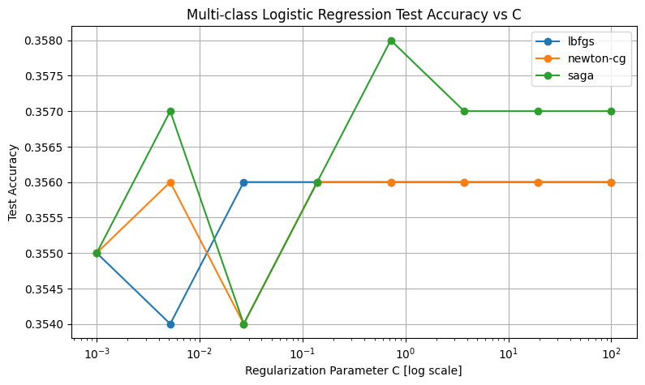

```python
import matplotlib.pyplot as plt
from sklearn.model_selection import train_test_split
from sklearn.compose import ColumnTransformer
from sklearn.preprocessing import OneHotEncoder, StandardScaler
from sklearn.pipeline import Pipeline
from sklearn.linear_model import LogisticRegression as SkLogReg
from sklearn.metrics import accuracy_score

import warnings
warnings.filterwarnings("ignore") #to suppress warnings to make notebook look cleaner

# multi-class target
target_col = "academic_level"   # 3 classes


drop_cols = ["student_id", "productivity_score", "exam_score", "burnout_level", target_col]
X = dfSelect.drop(columns=[c for c in drop_cols if c in dfSelect.columns]).copy()
y = dfSelect[target_col].copy()

# categorical vs numeric columns
cat_cols = X.select_dtypes(include=["object", "category", "string", "bool"]).columns.tolist()
num_cols = [c for c in X.columns if c not in cat_cols]

# Preprocess
preprocess = ColumnTransformer(
    transformers=[
        ("num", StandardScaler(), num_cols),
        ("cat", OneHotEncoder(handle_unknown="ignore"), cat_cols),
    ],
    remainder="drop"
)

# train/test split
X_train, X_test, y_train, y_test = train_test_split(
    X, y,
    test_size=0.2,
    random_state=42,
    stratify=y
)

# Tune C  solver and visualize performance
C_values = np.logspace(-3, 2, 8)
solvers = ["lbfgs", "newton-cg", "saga"]  # multi class solvers has to be 'liblinear', 'sag', 'newton-cg', 'saga', 'lbfgs', or 'newton-cholesky'

results = {s: [] for s in solvers}

best = {"solver": None, "C": None, "acc": -1}

for solver in solvers:
    for C in C_values:
        pipe = Pipeline(steps=[
            ("prep", preprocess),
            ("clf", SkLogReg(
                C=float(C),
                solver=solver,
                penalty="l2",
                multi_class="multinomial",
                max_iter=3000,
                n_jobs=None
            ))
        ])

        pipe.fit(X_train, y_train)
        y_pred = pipe.predict(X_test)
        acc = accuracy_score(y_test, y_pred)

        results[solver].append(acc)

        if acc > best["acc"]:
            best.update({"solver": solver, "C": float(C), "acc": float(acc)})

print("Best configuration:")
print(best)

# Plot Accuracy vs C for each solver
plt.figure(figsize=(9, 5))
for solver in solvers:
    plt.plot(C_values, results[solver], marker="o", label=solver)

plt.xscale("log")
plt.xlabel("Regularization Parameter C [log scale]")
plt.ylabel("Test Accuracy")
plt.title("Multi-class Logistic Regression Test Accuracy vs C")
plt.grid(True)
plt.legend()
plt.show()
```

### Analysis

Thid method could possibly introduce data snooping because the test dataset is repeatedly used during the parameter tuning process. The purpose of the test dataset is to evaluate the models performance on unseen data, but when it's used multiple times to select parameters, it indirectly influences the model selection process. This can lead to overly optimistic estimates of model performance. A more statistically sound approach would be to use a validation set or cross validation on the training data to select the best hyperparameters, and after the parameters are finalized, the model can be evaluated once on the test dataset to obtain an unbiased estimate of generalization performance.

```python
import time
from scipy import sparse

X_train_processed = preprocess.fit_transform(X_train)
X_test_processed = preprocess.transform(X_test)

if sparse.issparse(X_train_processed):
    X_train_processed = X_train_processed.toarray()

if sparse.issparse(X_test_processed):
    X_test_processed = X_test_processed.toarray()

# Best parameter
best_solver = best["solver"]
best_C = best["C"]

# Train logistic regression
start = time.time()
my_lr = LogisticRegression(
    eta=0.1,
    iterations=1500,
    solver='steepest',

    C=best_C
)

my_lr.fit(X_train_processed, y_train)

my_train_time = time.time() - start

y_pred_my = my_lr.predict(X_test_processed)
my_accuracy = accuracy_score(y_test, y_pred_my)

# Train sklearn logistic regression
start = time.time()

sk_lr = SkLogReg(
    solver=best_solver,
    C=best_C,
    max_iter=3000
)

sk_lr.fit(X_train_processed, y_train)

sk_train_time = time.time() - start

y_pred_sk = sk_lr.predict(X_test_processed)
sk_accuracy = accuracy_score(y_test, y_pred_sk)
print("Custom Logistic Regression")
print("Accuracy:", my_accuracy)
print("Training time:", my_train_time)

print("Sklearn Logistic Regression")
print("Accuracy:", sk_accuracy)
print("Training time:", sk_train_time)
```

```
Custom Logistic Regression
Accuracy: 0.357
Training time: 87.08797836303711
Sklearn Logistic Regression
Accuracy: 0.358
Training time: 0.0178067684173584
```

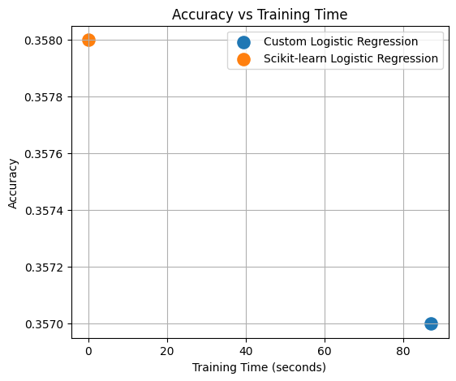

```python
#adding some plots to visualize the results

plt.figure(figsize=(6,5))

plt.scatter(my_train_time, my_accuracy, label="Custom Logistic Regression", s=120)
plt.scatter(sk_train_time, sk_accuracy, label="Scikit-learn Logistic Regression", s=120)

plt.xlabel("Training Time (seconds)")
plt.ylabel("Accuracy")
plt.title("Accuracy vs Training Time")
plt.legend()
plt.grid(True)

plt.show()
```

### Analysis

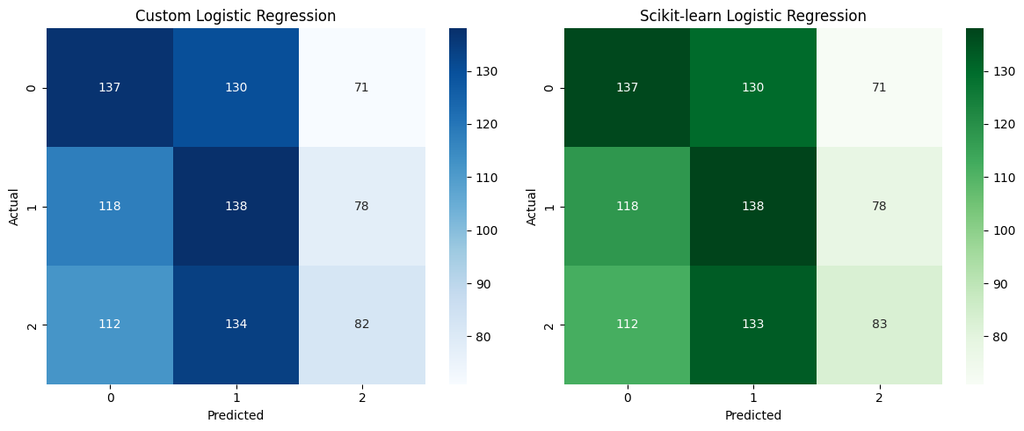

```python
from sklearn.metrics import confusion_matrix
import seaborn as sns

cm_custom = confusion_matrix(y_test, y_pred_my)
cm_sklearn = confusion_matrix(y_test, y_pred_sk)

fig, axes = plt.subplots(1,2, figsize=(12,5))

sns.heatmap(cm_custom, annot=True, fmt="d", cmap="Blues", ax=axes[0])
axes[0].set_title("Custom Logistic Regression")
axes[0].set_xlabel("Predicted")
axes[0].set_ylabel("Actual")

sns.heatmap(cm_sklearn, annot=True, fmt="d", cmap="Greens", ax=axes[1])
axes[1].set_title("Scikit-learn Logistic Regression")
axes[1].set_xlabel("Predicted")
axes[1].set_ylabel("Actual")

plt.tight_layout()
plt.show()
```

### Analysis

This confusion matrix shows the classification results for both the custom logistic regression implementation and the scikitlearn implementation, and the matrices are very similiar, which shows that both models produce very similar predictions.

Both models had a tendency to predict class 1 more often than they would predict other classes, which suggests that features may not strongly distinguish between the classes. The similarity between the two matrices confirms that the custom implementation and the scikit-learn implementation behave almost the same in terms of classification decisions, despite the large difference in training time.

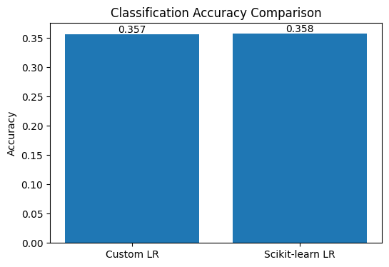

```python
models = ["Custom LR", "Scikit-learn LR"]
accuracies = [my_accuracy, sk_accuracy]

plt.figure(figsize=(6,4))
plt.bar(models, accuracies)

plt.ylabel("Accuracy")
plt.title("Classification Accuracy Comparison")

for i,v in enumerate(accuracies):
    plt.text(i, v + 0.002, f"{v:.3f}", ha='center')

plt.show()
```

### Analysis

The classification accuracy comparison shows the custom logistic regression model achieved an accuracy of approximately 0.357, compared to the scikit-learn implementation, which achieved a slightly higher accuracy of 0.358. The difference in accuracy is miniscule, which indicates that both implementations produce nearly identical predictive performance. This means that the custom implementation successfully replicates the behavior of logistic regression. When combined with the training time comparison, the results demonstrate that the primary advantage of the scikit-learn implementation is its computational efficiency rather than a significant improvement in classification performance.

# Deployment

On top of efficiency, third party libraries like scikit-learn are generally well tested, widely used, and actively maintained, which increases reliability within production environments. These implementations also give additional features like improved numerical stability, advanced optimization algorithms, and better integration with other machine learning tools.

So even though the custom implementation is valuable for educational purposes and understanding the mechanics of logistic regression optimization, the scikit-learn implementation would be the better choice for deployment in a production machine learning system because of its efficiency, reliability, and scalability.

# Exceptional Work

```
MSE Logistic Regression
Accuracy 0.335
Training time 2.1876327991485596
```

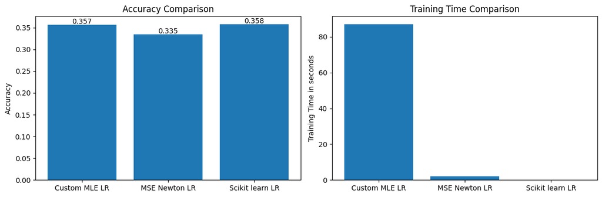

```python
class MSEBinaryLogisticRegression(BinaryLogisticRegressionBase):
    def __str__(self):
        if hasattr(self, 'w_'):
            return 'Binary Logistic Regression (MSE and Newton) with coefficients: ' + str(self.w_)
        else:
            return 'Untrained Binary Logistic Regression (MSE and Newton) Object'

    @staticmethod
    def _sigmoid(theta):
        return expit(theta)

    def _get_gradient(self, X, y):
        # X already includes intercept
        p = self.predict_proba(X, add_intercept=False).ravel()   # predicted probs
        error_term = (p - y) * p * (1 - p) # chain rule for MSE
        grad = X.T @ error_term[:, np.newaxis] / len(y)

        #L2 regularization
        grad[1:] += 2 * self.C * self.w_[1:]
        return grad

    def _get_hessian(self, X, y):
        p = self.predict_proba(X, add_intercept=False).ravel()

        # d approx
        d = (p * (1 - p))**2

        H = X.T @ np.diag(d) @ X / len(y)

        #L2 regularization
        reg = np.zeros((X.shape[1], X.shape[1]))
        reg[1:, 1:] = 2 * self.C * np.eye(X.shape[1] - 1)
        H += reg

        return H

    def fit(self, X, y):
        Xb = self._add_intercept(X)
        num_samples, num_features = Xb.shape
        self.w_ = np.zeros((num_features, 1))

        y = np.array(y).ravel()

        for _ in range(self.iters):
            grad = self._get_gradient(Xb, y)
            H = self._get_hessian(Xb, y)
            self.w_ -= pinv(H) @ grad
        return self

class MSELogisticRegressionOVA:
    def __init__(self, iterations=30, C=1.0):
        self.iters = iterations
        self.C = C

    def __str__(self):
        if hasattr(self, 'w_'):
            return 'Multiclass Logistic Regression'
        else:
            return 'Untrained Multiclass Logistic Rregression'

    def fit(self, X, y):
        self.unique_ = np.unique(y)
        self.classifiers_ = []

        for cls in self.unique_:
            y_binary = (y == cls).astype(int)

            clf = MSEBinaryLogisticRegression(
                eta=0.1,
                iterations=self.iters,
                C=self.C
            )
            clf.fit(X, y_binary)
            self.classifiers_.append(clf)

        self.w_ = np.hstack([clf.w_ for clf in self.classifiers_]).T
        return self

    def predict_proba(self, X):
        probs = [clf.predict_proba(X) for clf in self.classifiers_]
        return np.hstack(probs)

    def predict(self, X):
        probs = self.predict_proba(X)
        return self.unique_[np.argmax(probs, axis=1)]


# MSE newton one vs all
start = time.time()

mse_lr = MSELogisticRegressionOVA(iterations=20, C=best_C)
mse_lr.fit(X_train_processed, y_train)

mse_train_time = time.time() - start
y_pred_mse = mse_lr.predict(X_test_processed)
mse_accuracy = accuracy_score(y_test, y_pred_mse)

print("MSE Logistic Regression")
print("Accuracy", mse_accuracy)
print("Training time", mse_train_time)

models = ["Custom MLE LR", "MSE Newton LR", "Scikit learn LR"]
accs = [my_accuracy, mse_accuracy, sk_accuracy]
times = [my_train_time, mse_train_time, sk_train_time]

plt.figure(figsize=(12,4))

plt.subplot(1,2,1)
plt.bar(models, accs)
plt.ylabel("Accuracy")
plt.title("Accuracy Comparison")

for i, v in enumerate(accs):
    plt.text(i, v + 0.002, f"{v:.3f}", ha='center')

plt.subplot(1,2,2)
plt.bar(models, times)
plt.ylabel("Training Time in seconds")
plt.title("Training Time Comparison")

plt.tight_layout()
plt.show()
```

### Analysis

Logistic regression was implemented using a mean squared error (MSE) objective function optimized with Newton’s method and then the results were compared against the original maximum likelihood implementation and the scikit-learn implementation.

The MSE logistic regression achieved an accuracy of 0.335, which was lower than the maximum likelihood implementations, which suggests the MSE is less suitable for classification problems, and the maximum likelihood objective is better for capturing the relationship between predicted probabilities and class labels.